# R for Data Science

## This is a tutorial I will expand upon while I practice using `dplyr`

```r
library("dplyr")
```

```r
library("downloader")
url <- "https://raw.githubusercontent.com/genomicsclass/dagdata/master/inst/extdata/msleep_ggplot2.csv"
filename <- "msleep_ggplot2.csv"
```

```r
if (!file.exists(filename)) download(url,filename)
msleep <- read.csv("msleep_ggplot2.csv")
head(msleep)
```

```
##                         name      genus  vore        order conservation
## 1                    Cheetah   Acinonyx carni    Carnivora           lc
## 2                 Owl monkey      Aotus  omni     Primates         <NA>
## 3            Mountain beaver Aplodontia herbi     Rodentia           nt
## 4 Greater short-tailed shrew    Blarina  omni Soricomorpha           lc
## 5                        Cow        Bos herbi Artiodactyla domesticated
## 6           Three-toed sloth   Bradypus herbi       Pilosa         <NA>
##   sleep_total sleep_rem sleep_cycle awake brainwt  bodywt
## 1        12.1        NA          NA  11.9      NA  50.000
## 2        17.0       1.8          NA   7.0 0.01550   0.480
## 3        14.4       2.4          NA   9.6      NA   1.350
## 4        14.9       2.3   0.1333333   9.1 0.00029   0.019
## 5         4.0       0.7   0.6666667  20.0 0.42300 600.000
## 6        14.4       2.2   0.7666667   9.6      NA   3.850
```

## Important `dplyr` verbs

These `dplyr` verbs are important to remember:

- `select()`
- `filter()`
- `arrange()`
- `mutate()`
- `summarise()`
- `group_by()`

| Verb | Description |
| --- | --- |
| `select()` | Choose columns |
| `filter()` | Choose rows |
| `arrange()` | Re-order or arrange |
| `mutate()` | Create new columns |
| `summarise()` | Summarise values |
| `group_by()` | Like SQL `group by` |

### Selecting columns using `select()`

Select the `name` and `sleep_total` columns:

```r
sleepData <- select(msleep, name, sleep_total)
head(sleepData)
```

```
##                         name sleep_total
## 1                    Cheetah        12.1
## 2                 Owl monkey        17.0
## 3            Mountain beaver        14.4
## 4 Greater short-tailed shrew        14.9
## 5                        Cow         4.0
## 6           Three-toed sloth        14.4
```

Select all but the `name` column

```r
head(select(msleep, -name))
```

```
##        genus  vore        order conservation sleep_total sleep_rem
## 1   Acinonyx carni    Carnivora           lc        12.1        NA
## 2      Aotus  omni     Primates         <NA>        17.0       1.8
## 3 Aplodontia herbi     Rodentia           nt        14.4       2.4
## 4    Blarina  omni Soricomorpha           lc        14.9       2.3
## 5        Bos herbi Artiodactyla domesticated         4.0       0.7
## 6   Bradypus herbi       Pilosa         <NA>        14.4       2.2
##   sleep_cycle awake brainwt  bodywt
## 1          NA  11.9      NA  50.000
## 2          NA   7.0 0.01550   0.480
## 3          NA   9.6      NA   1.350
## 4   0.1333333   9.1 0.00029   0.019
## 5   0.6666667  20.0 0.42300 600.000
## 6   0.7666667   9.6      NA   3.850
```

Select a range of columns using the `:` operator

```r
head(select(msleep, name:order))
```

```
##                         name      genus  vore        order
## 1                    Cheetah   Acinonyx carni    Carnivora
## 2                 Owl monkey      Aotus  omni     Primates
## 3            Mountain beaver Aplodontia herbi     Rodentia
## 4 Greater short-tailed shrew    Blarina  omni Soricomorpha
## 5                        Cow        Bos herbi Artiodactyla
## 6           Three-toed sloth   Bradypus herbi       Pilosa
```

#### Other matching criteria

Select all columns starting with the string “sl” using the `starts_with()` function

```r
head(select(msleep, starts_with("sl")))
```

```
##   sleep_total sleep_rem sleep_cycle
## 1        12.1        NA          NA
## 2        17.0       1.8          NA
## 3        14.4       2.4          NA
## 4        14.9       2.3   0.1333333
## 5         4.0       0.7   0.6666667
## 6        14.4       2.2   0.7666667
```

Do something similar with `ends_with()`

```r
head(select(msleep, ends_with("wt")))
```

```
##   brainwt  bodywt
## 1      NA  50.000
## 2 0.01550   0.480
## 3      NA   1.350
## 4 0.00029   0.019
## 5 0.42300 600.000
## 6      NA   3.850
```

`contains()`

```r
head(select(msleep, contains("_")))
```

```
##   sleep_total sleep_rem sleep_cycle
## 1        12.1        NA          NA
## 2        17.0       1.8          NA
## 3        14.4       2.4          NA
## 4        14.9       2.3   0.1333333
## 5         4.0       0.7   0.6666667
## 6        14.4       2.2   0.7666667
```

`matches()` for regular expressions

```r
head(select(msleep, matches("*o[rn]*")))
```

```
##    vore        order conservation sleep_total  bodywt
## 1 carni    Carnivora           lc        12.1  50.000
## 2  omni     Primates         <NA>        17.0   0.480
## 3 herbi     Rodentia           nt        14.4   1.350
## 4  omni Soricomorpha           lc        14.9   0.019
## 5 herbi Artiodactyla domesticated         4.0 600.000
## 6 herbi       Pilosa         <NA>        14.4   3.850
```

or `one_of()`

```r
head(select(msleep, one_of(c("name", "order"))))
```

```
##                         name        order
## 1                    Cheetah    Carnivora
## 2                 Owl monkey     Primates
## 3            Mountain beaver     Rodentia
## 4 Greater short-tailed shrew Soricomorpha
## 5                        Cow Artiodactyla
## 6           Three-toed sloth       Pilosa
```

Note this last could also have been created by

```r
head(select(msleep, name, order))
```

```
##                         name        order
## 1                    Cheetah    Carnivora
## 2                 Owl monkey     Primates
## 3            Mountain beaver     Rodentia
## 4 Greater short-tailed shrew Soricomorpha
## 5                        Cow Artiodactyla
## 6           Three-toed sloth       Pilosa
```

And a programmatically almost useless `everything()`

```r
head(select(msleep, everything()))
```

```
##                         name      genus  vore        order conservation
## 1                    Cheetah   Acinonyx carni    Carnivora           lc
## 2                 Owl monkey      Aotus  omni     Primates         <NA>
## 3            Mountain beaver Aplodontia herbi     Rodentia           nt
## 4 Greater short-tailed shrew    Blarina  omni Soricomorpha           lc
## 5                        Cow        Bos herbi Artiodactyla domesticated
## 6           Three-toed sloth   Bradypus herbi       Pilosa         <NA>
##   sleep_total sleep_rem sleep_cycle awake brainwt  bodywt
## 1        12.1        NA          NA  11.9      NA  50.000
## 2        17.0       1.8          NA   7.0 0.01550   0.480
## 3        14.4       2.4          NA   9.6      NA   1.350
## 4        14.9       2.3   0.1333333   9.1 0.00029   0.019
## 5         4.0       0.7   0.6666667  20.0 0.42300 600.000
## 6        14.4       2.2   0.7666667   9.6      NA   3.850
```

However, I am told that `everything()` is used to rearrange the order of columns without having to write them all out:

```r
head(select(msleep, starts_with("sleep"),everything()))
```

```
##   sleep_total sleep_rem sleep_cycle                       name      genus
## 1        12.1        NA          NA                    Cheetah   Acinonyx
## 2        17.0       1.8          NA                 Owl monkey      Aotus
## 3        14.4       2.4          NA            Mountain beaver Aplodontia
## 4        14.9       2.3   0.1333333 Greater short-tailed shrew    Blarina
## 5         4.0       0.7   0.6666667                        Cow        Bos
## 6        14.4       2.2   0.7666667           Three-toed sloth   Bradypus
##    vore        order conservation awake brainwt  bodywt
## 1 carni    Carnivora           lc  11.9      NA  50.000
## 2  omni     Primates         <NA>   7.0 0.01550   0.480
## 3 herbi     Rodentia           nt   9.6      NA   1.350
## 4  omni Soricomorpha           lc   9.1 0.00029   0.019
## 5 herbi Artiodactyla domesticated  20.0 0.42300 600.000
## 6 herbi       Pilosa         <NA>   9.6      NA   3.850
```

## Selecting rows using `filter()`

In SQL parlance “SELECT columns FROM table WHERE condition” this is part of the WHERE statement

```r
filter(msleep, sleep_total >= 16)
```

```
##                     name        genus    vore           order conservation
## 1             Owl monkey        Aotus    omni        Primates         <NA>
## 2   Long-nosed armadillo      Dasypus   carni       Cingulata           lc
## 3 North American Opossum    Didelphis    omni Didelphimorphia           lc
## 4          Big brown bat    Eptesicus insecti      Chiroptera           lc
## 5   Thick-tailed opposum   Lutreolina   carni Didelphimorphia           lc
## 6       Little brown bat       Myotis insecti      Chiroptera         <NA>
## 7        Giant armadillo   Priodontes insecti       Cingulata           en
## 8 Arctic ground squirrel Spermophilus   herbi        Rodentia           lc
##   sleep_total sleep_rem sleep_cycle awake brainwt bodywt
## 1        17.0       1.8          NA   7.0 0.01550  0.480
## 2        17.4       3.1   0.3833333   6.6 0.01080  3.500
## 3        18.0       4.9   0.3333333   6.0 0.00630  1.700
## 4        19.7       3.9   0.1166667   4.3 0.00030  0.023
## 5        19.4       6.6          NA   4.6      NA  0.370
## 6        19.9       2.0   0.2000000   4.1 0.00025  0.010
## 7        18.1       6.1          NA   5.9 0.08100 60.000
## 8        16.6        NA          NA   7.4 0.00570  0.920
```

We could also do this with the pipe operator `%>%` as

```r
msleep %>%
  filter(sleep_total >= 16) %>%
  head
```

```
##                     name      genus    vore           order conservation
## 1             Owl monkey      Aotus    omni        Primates         <NA>
## 2   Long-nosed armadillo    Dasypus   carni       Cingulata           lc
## 3 North American Opossum  Didelphis    omni Didelphimorphia           lc
## 4          Big brown bat  Eptesicus insecti      Chiroptera           lc
## 5   Thick-tailed opposum Lutreolina   carni Didelphimorphia           lc
## 6       Little brown bat     Myotis insecti      Chiroptera         <NA>
##   sleep_total sleep_rem sleep_cycle awake brainwt bodywt
## 1        17.0       1.8          NA   7.0 0.01550  0.480
## 2        17.4       3.1   0.3833333   6.6 0.01080  3.500
## 3        18.0       4.9   0.3333333   6.0 0.00630  1.700
## 4        19.7       3.9   0.1166667   4.3 0.00030  0.023
## 5        19.4       6.6          NA   4.6      NA  0.370
## 6        19.9       2.0   0.2000000   4.1 0.00025  0.010
```

or playing around with it more

```r
msleep %>%
  filter(sleep_total >= 16, bodywt >= 1) %>%
  filter(vore %in% c("omni", "insecti")) %>%
  head
```

```
##                     name      genus    vore           order conservation
## 1 North American Opossum  Didelphis    omni Didelphimorphia           lc
## 2        Giant armadillo Priodontes insecti       Cingulata           en
##   sleep_total sleep_rem sleep_cycle awake brainwt bodywt
## 1        18.0       4.9   0.3333333   6.0  0.0063    1.7
## 2        18.1       6.1          NA   5.9  0.0810   60.0
```

or

```r
msleep %>%
  select(name, starts_with("sl")) %>%
  filter(sleep_total >= 16) %>%
  head
```

```
##                     name sleep_total sleep_rem sleep_cycle
## 1             Owl monkey        17.0       1.8          NA
## 2   Long-nosed armadillo        17.4       3.1   0.3833333
## 3 North American Opossum        18.0       4.9   0.3333333
## 4          Big brown bat        19.7       3.9   0.1166667
## 5   Thick-tailed opposum        19.4       6.6          NA
## 6       Little brown bat        19.9       2.0   0.2000000
```

Note that filter can use the boolean operators `>=`, `>`, `<`, `<=`, `!=`, `==`, `%in%` to create the conditions

### Using `group_by()`

We can use the `group_by()` functionality with the `summarise()` to create new columns based on summary statistics

```r
msleep %>%
  group_by(order) %>%
  summarise(avg_sleep = mean(sleep_total),
            min_sleep = min(sleep_total),
            max_sleep = max(sleep_total),
            total = n())
```

```
## # A tibble: 19 x 5
##    order           avg_sleep min_sleep max_sleep total
##    <fct>               <dbl>     <dbl>     <dbl> <int>
##  1 Afrosoricida        15.6       15.6      15.6     1
##  2 Artiodactyla         4.52       1.9       9.1     6
##  3 Carnivora           10.1        3.5      15.8    12
##  4 Cetacea              4.5        2.7       5.6     3
##  5 Chiroptera          19.8       19.7      19.9     2
##  6 Cingulata           17.8       17.4      18.1     2
##  7 Didelphimorphia     18.7       18        19.4     2
##  8 Diprotodontia       12.4       11.1      13.7     2
##  9 Erinaceomorpha      10.2       10.1      10.3     2
## 10 Hyracoidea           5.67       5.3       6.3     3
## 11 Lagomorpha           8.4        8.4       8.4     1
## 12 Monotremata          8.6        8.6       8.6     1
## 13 Perissodactyla       3.47       2.9       4.4     3
## 14 Pilosa              14.4       14.4      14.4     1
## 15 Primates            10.5        8        17      12
## 16 Proboscidea          3.6        3.3       3.9     2
## 17 Rodentia            12.5        7        16.6    22
## 18 Scandentia           8.9        8.9       8.9     1
## 19 Soricomorpha        11.1        8.4      14.9     5
```

More on `summarise()`:

`n()` returns the length of the vector, `first()` and `last()` return the first and last values in the vector, and `n_distinct()` is the number of distinct values in the vector.

Now putting everything together:

```r
msleep %>%
  group_by(order) %>%
  summarise(avg_sleep = mean(sleep_total),
            min_sleep = min(sleep_total),
            max_sleep = max(sleep_total),
            total = n()) %>%
  filter(total > 1) %>%
  arrange(desc(total), desc(avg_sleep))
```

```
## # A tibble: 14 x 5
##    order           avg_sleep min_sleep max_sleep total
##    <fct>               <dbl>     <dbl>     <dbl> <int>
##  1 Rodentia            12.5        7        16.6    22
##  2 Primates            10.5        8        17      12
##  3 Carnivora           10.1        3.5      15.8    12
##  4 Artiodactyla         4.52       1.9       9.1     6
##  5 Soricomorpha        11.1        8.4      14.9     5
##  6 Hyracoidea           5.67       5.3       6.3     3
##  7 Cetacea              4.5        2.7       5.6     3
##  8 Perissodactyla       3.47       2.9       4.4     3
##  9 Chiroptera          19.8       19.7      19.9     2
## 10 Didelphimorphia     18.7       18        19.4     2
## 11 Cingulata           17.8       17.4      18.1     2
## 12 Diprotodontia       12.4       11.1      13.7     2
## 13 Erinaceomorpha      10.2       10.1      10.3     2
## 14 Proboscidea          3.6        3.3       3.9     2
```

## Joins

```r
library(tidyverse)
library(nycflights13)
```

The tables are

```r
airlines
```

```
## # A tibble: 16 x 2
##    carrier name
##    <chr>   <chr>
##  1 9E      Endeavor Air Inc.
##  2 AA      American Airlines Inc.
##  3 AS      Alaska Airlines Inc.
##  4 B6      JetBlue Airways
##  5 DL      Delta Air Lines Inc.
##  6 EV      ExpressJet Airlines Inc.
##  7 F9      Frontier Airlines Inc.
##  8 FL      AirTran Airways Corporation
##  9 HA      Hawaiian Airlines Inc.
## 10 MQ      Envoy Air
## 11 OO      SkyWest Airlines Inc.
## 12 UA      United Air Lines Inc.
## 13 US      US Airways Inc.
## 14 VX      Virgin America
## 15 WN      Southwest Airlines Co.
## 16 YV      Mesa Airlines Inc.
```

```r
airports
```

```
## # A tibble: 1,458 x 8
##    faa   name                   lat    lon   alt    tz dst   tzone
##    <chr> <chr>                <dbl>  <dbl> <int> <dbl> <chr> <chr>
##  1 04G   Lansdowne Airport     41.1  -80.6  1044    -5 A     America/New_…
##  2 06A   Moton Field Municip…  32.5  -85.7   264    -6 A     America/Chic…
##  3 06C   Schaumburg Regional   42.0  -88.1   801    -6 A     America/Chic…
##  4 06N   Randall Airport       41.4  -74.4   523    -5 A     America/New_…
##  5 09J   Jekyll Island Airpo…  31.1  -81.4    11    -5 A     America/New_…
##  6 0A9   Elizabethton Munici…  36.4  -82.2  1593    -5 A     America/New_…
##  7 0G6   Williams County Air…  41.5  -84.5   730    -5 A     America/New_…
##  8 0G7   Finger Lakes Region…  42.9  -76.8   492    -5 A     America/New_…
##  9 0P2   Shoestring Aviation…  39.8  -76.6  1000    -5 U     America/New_…
## 10 0S9   Jefferson County In…  48.1 -123.    108    -8 A     America/Los_…
## # ... with 1,448 more rows
```

```r
planes
```

```
## # A tibble: 3,322 x 9
##    tailnum  year type      manufacturer  model  engines seats speed engine
##    <chr>   <int> <chr>     <chr>         <chr>    <int> <int> <int> <chr>
##  1 N10156   2004 Fixed wi… EMBRAER       EMB-1…       2    55    NA Turbo…
##  2 N102UW   1998 Fixed wi… AIRBUS INDUS… A320-…       2   182    NA Turbo…
##  3 N103US   1999 Fixed wi… AIRBUS INDUS… A320-…       2   182    NA Turbo…
##  4 N104UW   1999 Fixed wi… AIRBUS INDUS… A320-…       2   182    NA Turbo…
##  5 N10575   2002 Fixed wi… EMBRAER       EMB-1…       2    55    NA Turbo…
##  6 N105UW   1999 Fixed wi… AIRBUS INDUS… A320-…       2   182    NA Turbo…
##  7 N107US   1999 Fixed wi… AIRBUS INDUS… A320-…       2   182    NA Turbo…
##  8 N108UW   1999 Fixed wi… AIRBUS INDUS… A320-…       2   182    NA Turbo…
##  9 N109UW   1999 Fixed wi… AIRBUS INDUS… A320-…       2   182    NA Turbo…
## 10 N110UW   1999 Fixed wi… AIRBUS INDUS… A320-…       2   182    NA Turbo…
## # ... with 3,312 more rows
```

```r
weather
```

```
## # A tibble: 26,130 x 15
##    origin  year month   day  hour  temp  dewp humid wind_dir wind_speed
##    <chr>  <dbl> <dbl> <int> <int> <dbl> <dbl> <dbl>    <dbl>      <dbl>
##  1 EWR     2013     1     1     0  37.0  21.9  54.0      230      10.4
##  2 EWR     2013     1     1     1  37.0  21.9  54.0      230      13.8
##  3 EWR     2013     1     1     2  37.9  21.9  52.1      230      12.7
##  4 EWR     2013     1     1     3  37.9  23    54.5      230      13.8
##  5 EWR     2013     1     1     4  37.9  24.1  57.0      240      15.0
##  6 EWR     2013     1     1     6  39.0  26.1  59.4      270      10.4
##  7 EWR     2013     1     1     7  39.0  27.0  61.6      250       8.06
##  8 EWR     2013     1     1     8  39.0  28.0  64.4      240      11.5
##  9 EWR     2013     1     1     9  39.9  28.0  62.2      250      12.7
## 10 EWR     2013     1     1    10  39.0  28.0  64.4      260      12.7
## # ... with 26,120 more rows, and 5 more variables: wind_gust <dbl>,
## #   precip <dbl>, pressure <dbl>, visib <dbl>, time_hour <dttm>
```

These tables are connected as follows:

- `tailnum` connects `planes` and `flights`
- `carrier` connects `airlines` and `flights`
- `flights` connects to `airports` via `origin` and `dest` variables
- `weather` connects to `flights` via `origin`, `year`, `month`, `day`, and `hour`

Count the primary keys and check that they are indeed unique

```r
planes %>%
  count(tailnum)
```

```
## # A tibble: 3,322 x 2
##    tailnum     n
##    <chr>   <int>
##  1 N10156      1
##  2 N102UW      1
##  3 N103US      1
##  4 N104UW      1
##  5 N10575      1
##  6 N105UW      1
##  7 N107US      1
##  8 N108UW      1
##  9 N109UW      1
## 10 N110UW      1
## # ... with 3,312 more rows
```

add the filter to check uniqueness

```r
planes %>%
  count(tailnum) %>%
  filter(n>1)
```

```
## # A tibble: 0 x 2
## # ... with 2 variables: tailnum <chr>, n <int>
```

Do the same for weather

```r
weather %>%
  count(year, month, day, hour, origin) %>%
  filter(n>1)
```

```
## # A tibble: 0 x 6
## # ... with 6 variables: year <dbl>, month <dbl>, day <int>, hour <int>,
## #   origin <chr>, n <int>
```

Some tables have complex primary keys

```r
flights %>%
  count(year, month, day, flight) %>%
  filter(n>1)
```

```
## # A tibble: 29,768 x 5
##     year month   day flight     n
##    <int> <int> <int>  <int> <int>
##  1  2013     1     1      1     2
##  2  2013     1     1      3     2
##  3  2013     1     1      4     2
##  4  2013     1     1     11     3
##  5  2013     1     1     15     2
##  6  2013     1     1     21     2
##  7  2013     1     1     27     4
##  8  2013     1     1     31     2
##  9  2013     1     1     32     2
## 10  2013     1     1     35     2
## # ... with 29,758 more rows
```

So the flight number is not unique, are there every any more than 2 flights?

```r
flights %>%
  count(year, month, day, flight) %>%
  filter(n>2) %>%
  arrange(desc(n))
```

```
## # A tibble: 2,739 x 5
##     year month   day flight     n
##    <int> <int> <int>  <int> <int>
##  1  2013     1     1     27     4
##  2  2013     4    13   1639     4
##  3  2013     4    20   1639     4
##  4  2013     4    27   1639     4
##  5  2013     6     9     15     4
##  6  2013     6    10     15     4
##  7  2013     6    11     15     4
##  8  2013     6    12     15     4
##  9  2013     6    13     15     4
## 10  2013     6    14     15     4
## # ... with 2,729 more rows
```

So at least 2,729 flights have more than 2 (and up to 4) flights per day. Let’s add `hour`

```r
flights %>%
  count(year, month, day, flight, hour) %>%
  filter(n>1) %>%
  arrange(desc(n))
```

```
## # A tibble: 2,945 x 6
##     year month   day flight  hour     n
##    <int> <int> <int>  <int> <dbl> <int>
##  1  2013     1     1     11     7     2
##  2  2013     1     1     32    12     2
##  3  2013     1     1     87    19     2
##  4  2013     1     1    303     6     2
##  5  2013     1     1    645    19     2
##  6  2013     1     1    702    16     2
##  7  2013     1     1    715     7     2
##  8  2013     1     1    717     8     2
##  9  2013     1     1   1443    12     2
## 10  2013     1     1   4105    15     2
## # ... with 2,935 more rows
```

Wow, that was not even sufficient! Let’s add minute as well

```r
flights %>%
  count(year, month, day, flight, hour, minute) %>%
  filter(n>1)
```

```
## # A tibble: 113 x 7
##     year month   day flight  hour minute     n
##    <int> <int> <int>  <int> <dbl>  <dbl> <int>
##  1  2013     1     1     32    12     59     2
##  2  2013     1     1   1443    12      0     2
##  3  2013     1     2   1443    12      0     2
##  4  2013     1    11   1625    11     30     2
##  5  2013     1    14   1625    11     30     2
##  6  2013     1    18   1625    11     30     2
##  7  2013     1    21   1625    11     30     2
##  8  2013     1    25   1625    11     30     2
##  9  2013     1    28   1625    11     30     2
## 10  2013     2     1   1625    11     30     2
## # ... with 103 more rows
```

What about `tailnum`?

```r
flights %>%
  count(year, month, day, flight, tailnum, hour, minute) %>%
  filter(n>1)
```

```
## # A tibble: 0 x 8
## # ... with 8 variables: year <int>, month <int>, day <int>, flight <int>,
## #   tailnum <chr>, hour <dbl>, minute <dbl>, n <int>
```

Finally, this appears like it would be sufficient to create a primary key. It would be easiest to construct a primary key after doing this complete grouping, or just do a primary key by row number:

```r
flights %>%
  mutate(primary_key = row_number()) %>%
  select(primary_key, everything())
```

```
## # A tibble: 336,776 x 20
##    primary_key  year month   day dep_time sched_dep_time dep_delay
##          <int> <int> <int> <int>    <int>          <int>     <dbl>
##  1           1  2013     1     1      517            515         2
##  2           2  2013     1     1      533            529         4
##  3           3  2013     1     1      542            540         2
##  4           4  2013     1     1      544            545        -1
##  5           5  2013     1     1      554            600        -6
##  6           6  2013     1     1      554            558        -4
##  7           7  2013     1     1      555            600        -5
##  8           8  2013     1     1      557            600        -3
##  9           9  2013     1     1      557            600        -3
## 10          10  2013     1     1      558            600        -2
## # ... with 336,766 more rows, and 13 more variables: arr_time <int>,
## #   sched_arr_time <int>, arr_delay <dbl>, carrier <chr>, flight <int>,
## #   tailnum <chr>, origin <chr>, dest <chr>, air_time <dbl>,
## #   distance <dbl>, hour <dbl>, minute <dbl>, time_hour <dttm>
```

### Joins

```r
flights2 <- flights %>%
  select(year:day, hour, origin, dest, tailnum, carrier)
flights2
```

```
## # A tibble: 336,776 x 8
##     year month   day  hour origin dest  tailnum carrier
##    <int> <int> <int> <dbl> <chr>  <chr> <chr>   <chr>
##  1  2013     1     1     5 EWR    IAH   N14228  UA
##  2  2013     1     1     5 LGA    IAH   N24211  UA
##  3  2013     1     1     5 JFK    MIA   N619AA  AA
##  4  2013     1     1     5 JFK    BQN   N804JB  B6
##  5  2013     1     1     6 LGA    ATL   N668DN  DL
##  6  2013     1     1     5 EWR    ORD   N39463  UA
##  7  2013     1     1     6 EWR    FLL   N516JB  B6
##  8  2013     1     1     6 LGA    IAD   N829AS  EV
##  9  2013     1     1     6 JFK    MCO   N593JB  B6
## 10  2013     1     1     6 LGA    ORD   N3ALAA  AA
## # ... with 336,766 more rows
```

Now left join to get the full airline name

```r
flights2 %>%
  select(-origin, -dest) %>%
  left_join(airlines, by="carrier")
```

```
## # A tibble: 336,776 x 7
##     year month   day  hour tailnum carrier name
##    <int> <int> <int> <dbl> <chr>   <chr>   <chr>
##  1  2013     1     1     5 N14228  UA      United Air Lines Inc.
##  2  2013     1     1     5 N24211  UA      United Air Lines Inc.
##  3  2013     1     1     5 N619AA  AA      American Airlines Inc.
##  4  2013     1     1     5 N804JB  B6      JetBlue Airways
##  5  2013     1     1     6 N668DN  DL      Delta Air Lines Inc.
##  6  2013     1     1     5 N39463  UA      United Air Lines Inc.
##  7  2013     1     1     6 N516JB  B6      JetBlue Airways
##  8  2013     1     1     6 N829AS  EV      ExpressJet Airlines Inc.
##  9  2013     1     1     6 N593JB  B6      JetBlue Airways
## 10  2013     1     1     6 N3ALAA  AA      American Airlines Inc.
## # ... with 336,766 more rows
```

An example of a more complex `by` statement is

```r
flights2 %>%
  left_join(airports, by=c("dest"="faa"))
```

```
## # A tibble: 336,776 x 15
##     year month   day  hour origin dest  tailnum carrier name     lat   lon
##    <int> <int> <int> <dbl> <chr>  <chr> <chr>   <chr>   <chr>  <dbl> <dbl>
##  1  2013     1     1     5 EWR    IAH   N14228  UA      Georg…  30.0 -95.3
##  2  2013     1     1     5 LGA    IAH   N24211  UA      Georg…  30.0 -95.3
##  3  2013     1     1     5 JFK    MIA   N619AA  AA      Miami…  25.8 -80.3
##  4  2013     1     1     5 JFK    BQN   N804JB  B6      <NA>    NA    NA
##  5  2013     1     1     6 LGA    ATL   N668DN  DL      Harts…  33.6 -84.4
##  6  2013     1     1     5 EWR    ORD   N39463  UA      Chica…  42.0 -87.9
##  7  2013     1     1     6 EWR    FLL   N516JB  B6      Fort …  26.1 -80.2
##  8  2013     1     1     6 LGA    IAD   N829AS  EV      Washi…  38.9 -77.5
##  9  2013     1     1     6 JFK    MCO   N593JB  B6      Orlan…  28.4 -81.3
## 10  2013     1     1     6 LGA    ORD   N3ALAA  AA      Chica…  42.0 -87.9
## # ... with 336,766 more rows, and 4 more variables: alt <int>, tz <dbl>,
## #   dst <chr>, tzone <chr>
```

## Dates and Times

Here we use the `lubridate` package to deal with dates and times

```r
library(tidyverse)

library(lubridate)
library(nycflights13)
```

And see if it’s loaded correctly

```r
today()
```

```
## [1] "2018-06-04"
```

```r
now()
```

```
## [1] "2018-06-04 12:04:12 CDT"
```

Now load a csv file

```r
mtcars <- read_csv(readr_example("mtcars.csv"))
```

Use `lubridate` to parse strings into date-times:

```r
ymd("2017-01-31")
```

```
## [1] "2017-01-31"
```

```r
mdy("January 31st, 2017")
```

```
## [1] "2017-01-31"
```

```r
dmy("31-Jan-2018")
```

```
## [1] "2018-01-31"
```

They can also take unquoted numbers

```r
ymd(20180412)
```

```
## [1] "2018-04-12"
```

To create date-times, add an underscore and `h`, `m`, `s` or any combination of them

```r
ymd_hms("2018-01-31 20:11:29")
```

```
## [1] "2018-01-31 20:11:29 UTC"
```

```r
mdy_hm("01/31/2018 08:01")
```

```
## [1] "2018-01-31 08:01:00 UTC"
```

You can also supply a timezone

```r
ymd(2018-01-31, tz="UTC")
```

```
## [1] NA
```

From individual flight components:

```r
flights %>%
  select(year, month,day, hour, minute)
```

```
## # A tibble: 336,776 x 5
##     year month   day  hour minute
##    <int> <int> <int> <dbl>  <dbl>
##  1  2013     1     1     5     15
##  2  2013     1     1     5     29
##  3  2013     1     1     5     40
##  4  2013     1     1     5     45
##  5  2013     1     1     6      0
##  6  2013     1     1     5     58
##  7  2013     1     1     6      0
##  8  2013     1     1     6      0
##  9  2013     1     1     6      0
## 10  2013     1     1     6      0
## # ... with 336,766 more rows
```

```r
flights %>%
  select(year, month,day, hour, minute) %>%
  mutate(departure = make_datetime(year, month, day, hour, minute))
```

```
## # A tibble: 336,776 x 6
##     year month   day  hour minute departure
##    <int> <int> <int> <dbl>  <dbl> <dttm>
##  1  2013     1     1     5     15 2013-01-01 05:15:00
##  2  2013     1     1     5     29 2013-01-01 05:29:00
##  3  2013     1     1     5     40 2013-01-01 05:40:00
##  4  2013     1     1     5     45 2013-01-01 05:45:00
##  5  2013     1     1     6      0 2013-01-01 06:00:00
##  6  2013     1     1     5     58 2013-01-01 05:58:00
##  7  2013     1     1     6      0 2013-01-01 06:00:00
##  8  2013     1     1     6      0 2013-01-01 06:00:00
##  9  2013     1     1     6      0 2013-01-01 06:00:00
## 10  2013     1     1     6      0 2013-01-01 06:00:00
## # ... with 336,766 more rows
```

```r
make_datetime_100 <- function(year, month, day, time) {
  make_datetime(year, month, day, time %/% 100, time %% 100)
}

flights_dt <- flights %>%
  filter(!is.na(dep_time), !is.na(arr_time)) %>%
  mutate(
    dep_time = make_datetime_100(year, month, day, dep_time),
    arr_time = make_datetime_100(year, month, day, arr_time),
    sched_dep_time = make_datetime_100(year, month, day, sched_dep_time),
    sched_arr_time = make_datetime_100(year, month, day, sched_arr_time)
  ) %>%
  select(origin, dest, ends_with("delay"), ends_with("time"))

flights_dt
```

```
## # A tibble: 328,063 x 9
##    origin dest  dep_delay arr_delay dep_time
##    <chr>  <chr>     <dbl>     <dbl> <dttm>
##  1 EWR    IAH           2        11 2013-01-01 05:17:00
##  2 LGA    IAH           4        20 2013-01-01 05:33:00
##  3 JFK    MIA           2        33 2013-01-01 05:42:00
##  4 JFK    BQN          -1       -18 2013-01-01 05:44:00
##  5 LGA    ATL          -6       -25 2013-01-01 05:54:00
##  6 EWR    ORD          -4        12 2013-01-01 05:54:00
##  7 EWR    FLL          -5        19 2013-01-01 05:55:00
##  8 LGA    IAD          -3       -14 2013-01-01 05:57:00
##  9 JFK    MCO          -3        -8 2013-01-01 05:57:00
## 10 LGA    ORD          -2         8 2013-01-01 05:58:00
## # ... with 328,053 more rows, and 4 more variables: sched_dep_time <dttm>,
## #   arr_time <dttm>, sched_arr_time <dttm>, air_time <dbl>
```

Now visualize with ggplot

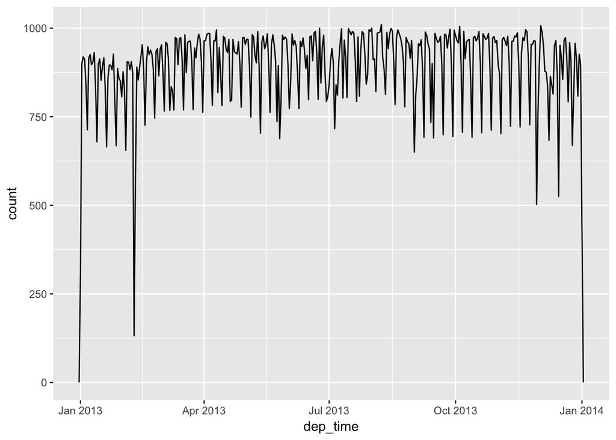

```r
flights_dt %>%
  ggplot(aes(dep_time)) +
  geom_freqpoly(binwidth = 86400)
```

or within a single day

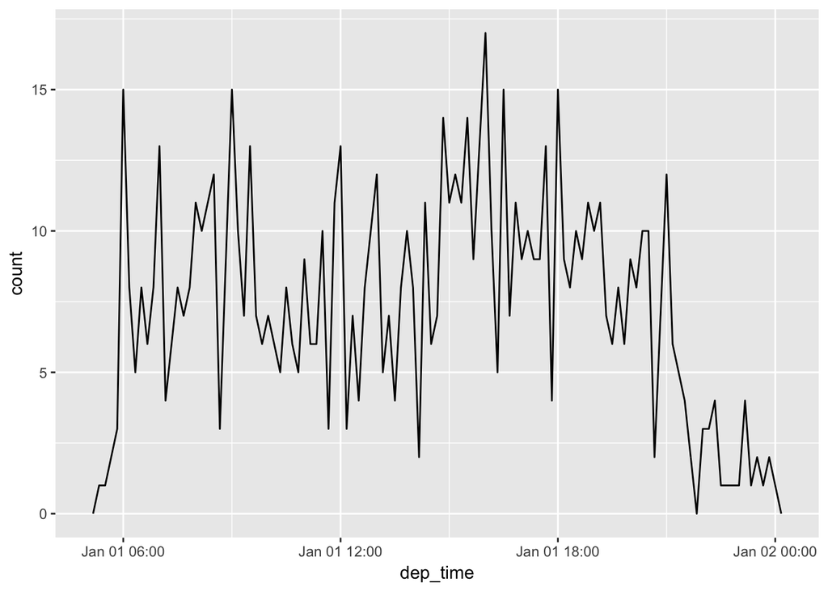

```r
flights_dt %>%
  filter(dep_time < ymd(20130102)) %>%
  ggplot(aes(dep_time)) +
  geom_freqpoly(binwidth = 600) # 600 s = 10 minutes
```

Switching between types:

```r
as_datetime(today())
```

```
## [1] "2018-06-04 UTC"
```

```r
as_date(now())
```

```
## [1] "2018-06-04"
```

also as numeric offsets from the Unix Epoch

```r
as_datetime(60*60*10)
```

```
## [1] "1970-01-01 10:00:00 UTC"
```

```r
as_date(365*10 + 2)
```

```
## [1] "1980-01-01"
```